# Customer Status Prediction Using Multi-Source Data Integration

CENG4515: Data Science and Analytics - Final Project

Doğa Değirmenci (210709003)

Hakan Kayacı (210709078)

Yeşim Arslan (220709030)

2026-01-13

# 1 Data Exploration and Visualization

## 1.1 Dataset Overview

This project integrates **9 CSV files** to predict customer status: **Churn**, **Onboarding**, or **Retained**.

| Metric | Value |
| --- | --- |
| Training Samples | 1,571 |
| Test Samples | 515 |
| Total Features | 19 (after integration) |
| Target Classes | 3 (Churn, Onboarding, Retained) |

## 1.2 Exploratory Data Analysis (EDA)

### 1.2.1 Target Variable Analysis

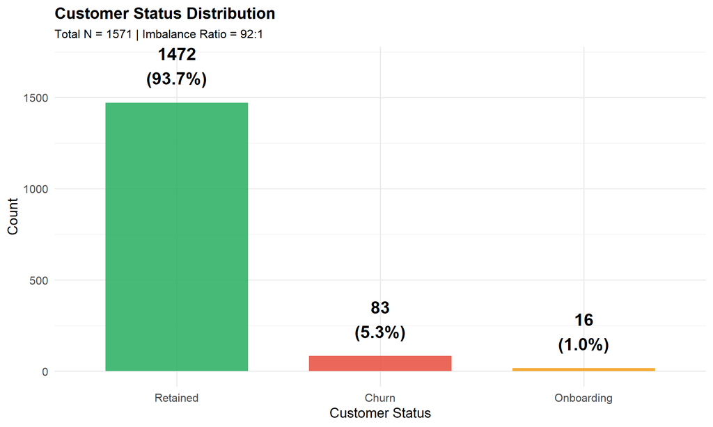

> **Key Finding**: Severe class imbalance (93.7% Retained) → SMOTE will be required later.

### 1.2.2 Financial Metrics by Status

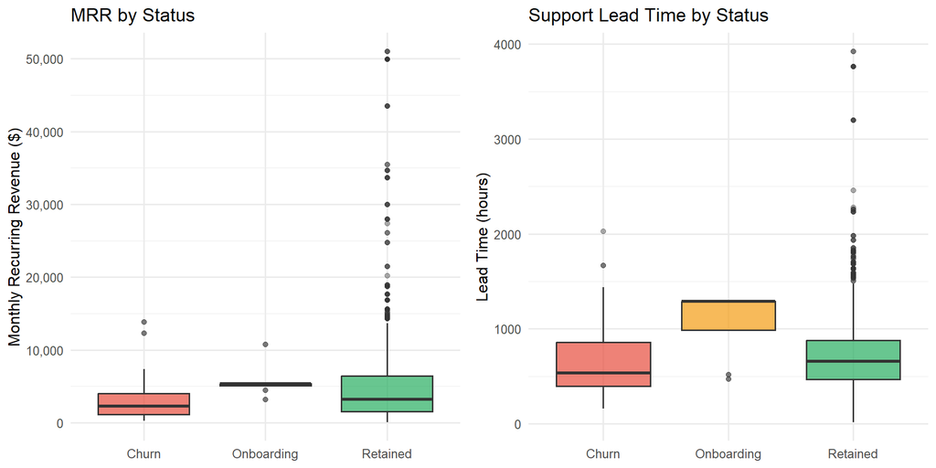

### 1.2.3 Customer Level Composition

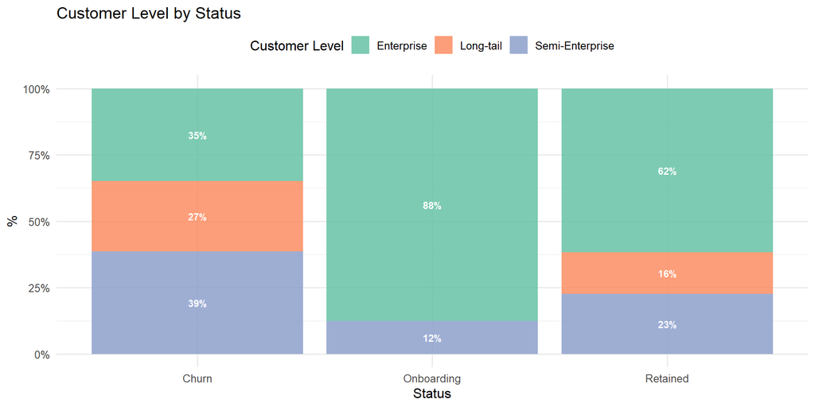

### 1.2.4 Correlation Heatmap

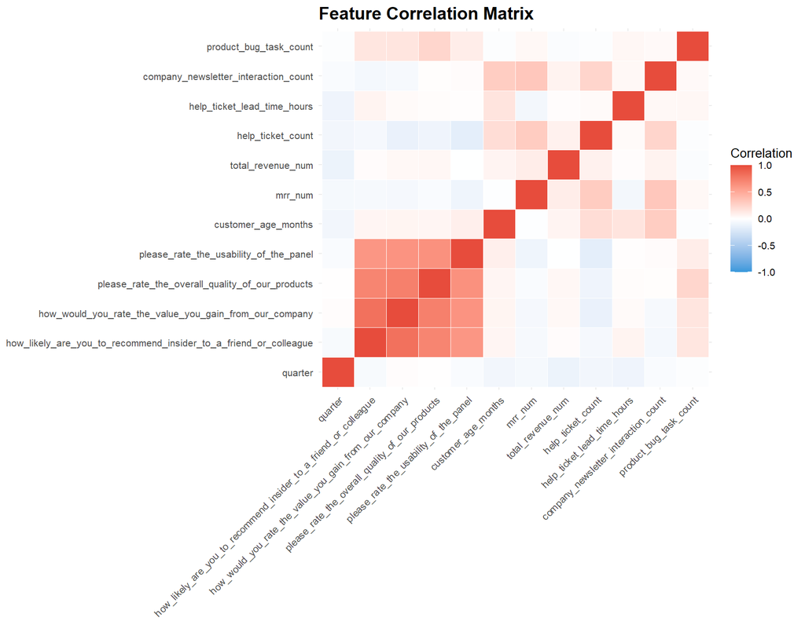

> **Insight**: Satisfaction variables highly correlated → will create composite `avg_satisfaction`.

# 2 Data Cleaning and Preprocessing

## 2.1 Data Integration Details

### 2.1.1 CSV File Structure & Join Strategy

Nine CSV files were integrated using `left_join` with `customer_id` as the primary key:

| Step | File | Rows | Key_Column | Join_Type |
| --- | --- | --- | --- | --- |
| 1 | satisfaction_scores | 1571 | customer_id | Base |
| 2 | demographics | 2068 | customer_id | LEFT JOIN |
| 3 | monthly_recurring_revenue | 1056 | customer_id | LEFT JOIN |
| 4 | revenue_history | 712 | customer_id | LEFT JOIN |
| 5 | support_tickets | 1072 | customer_id | LEFT JOIN |
| 6 | newsletter_engagement | 199 | customer_id | LEFT JOIN |
| 7 | bug_reports | 1571 | customer_id | LEFT JOIN |
| 8 | region_industry | 2068 | customer_id | LEFT JOIN |
| 9 | status_level (TARGET) | 2068 | customer_id | LEFT JOIN |

### 2.1.2 Key Challenges & Solutions:

**Challenge 1: Inconsistent ID Column Names** - Demographics file: `CUS ID`  
- Other files: `Customer ID`  
- **Solution**: Applied `janitor::clean_names()` → standardized to `customer_id`, then renamed `cus_id` → `customer_id`

**Challenge 2: Missing Customers in Some Files** - Not all customers exist in all files (e.g., only 199 newsletter records vs. 1,571 customers) - **Solution**: Used LEFT JOIN starting from satisfaction_scores (base) → preserves all 1,571 customers - Result: Missing values handled via imputation (see below)

**Challenge 3: No Duplicates Detected** - Verified: `sum(duplicated(customer_id)) = 0` after each join - Final integrated dataset: **1,571 unique customers** (training)

## 2.2 Missing Value Imputation Strategy

**CRITICAL**: All imputation done **WITHOUT using target variable (status)** to prevent data leakage.

Imputation Strategy (NO Target Leakage)

[output not shown]

# 3 Feature Engineering

Based on EDA, we created **13 new features**:

## 3.1 Financial Features

Financial Features

| Feature | Formula | Purpose |
| --- | --- | --- |
| log_mrr | log1p(mrr_num) | Normalize skew |
| log_total_revenue | log1p(total_revenue_num) | Normalize skew |
| revenue_per_ticket | total_revenue / (tickets + 1) | Value per support cost |

## 3.2 Customer Maturity Features

Maturity Features

| Feature | Formula | Purpose |
| --- | --- | --- |
| tickets_per_month | ticket_count / age_months | Support intensity |
| mrr_per_month | total_revenue / age_months | Revenue velocity |

## 3.3 Satisfaction Features

Satisfaction Features

| Feature | Formula | Purpose |
| --- | --- | --- |
| avg_satisfaction | mean(recommend, value, quality, usability) | Overall sentiment |
| satisfaction_sd | sd(recommend, value, quality, usability) | Consistency |

## 3.4 Support Quality Features

Support Features

| Feature | Formula | Purpose |
| --- | --- | --- |
| lead_time_per_ticket | lead_time_hours / (tickets + 1) | Avg resolution time |
| high_support | tickets > median(tickets) | Binary support flag |

## 3.5 Engagement Features

Engagement Features

| Feature | Formula | Purpose |
| --- | --- | --- |
| engaged_newsletter | newsletter_count > 0 | Binary engagement |
| bugs_per_month | bug_tasks / age_months | Product quality experience |

## 3.6 Risk Flags

Risk Flags

| Feature | Formula | Purpose |
| --- | --- | --- |
| low_value_high_pain | (mrr < median) & (tickets > median) | Low revenue + high support |
| mature_unhappy_customer | (age > median) & (satisfaction < median) | Established + unhappy |

## 3.7 Feature Engineering Summary

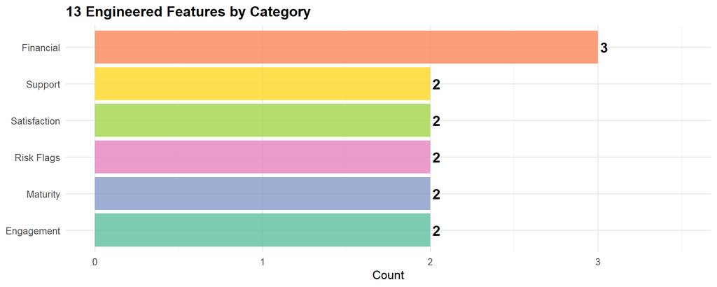

# 4 Train/Validation Split & SMOTE

## 4.1 Stratified Split

**AFTER** feature engineering, we split the data to preserve class distribution:

Stratified 80/20 Split

| Stage | Samples | Churn | Onboarding | Retained | Churn_Pct |
| --- | --- | --- | --- | --- | --- |
| Full Training Data | 1571 | 83 | 16 | 1472 | 5.3% |
| Training Set (80%) | 1257 | 67 | 13 | 1177 | 5.3% |
| Validation Set (20%) | 314 | 16 | 3 | 295 | 5.1% |

**Method**: `caret::createDataPartition(status, p=0.80)` → ensures class proportions preserved.

## 4.2 SMOTE Application (Training Set ONLY)

**CRITICAL**: SMOTE applied **ONLY to training set** to prevent data leakage. Validation set kept original distribution.

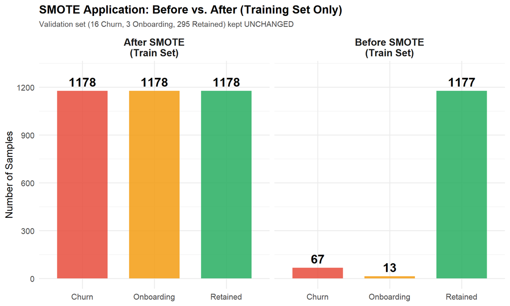

> **Why?** Validation must reflect real-world class distribution. SMOTE on validation would artificially inflate performance metrics.

# 5 Modeling

## 5.1 Model Selection

| Model | Type | Strengths | Configuration |
| --- | --- | --- | --- |
| Multinomial Logistic Regression | Linear (GLM) | Fast, interpretable | Elastic Net (α=0.5) |
| Random Forest | Nonlinear (Ensemble) | Captures interactions | Constrained (nodesize=20, maxnodes=20) |

## 5.2 Hyperparameter Tuning

**Random Forest: Complexity-Constrained Configuration**

```r
ntree = 100       # Reduced trees
nodesize = 20     # Min 20 samples per leaf
maxnodes = 20     # Max 20 terminal nodes
sampsize = 0.60*N # 60% bootstrap
mtry = c(5, 7)    # Features per split
```

# 6 Performance Evaluation

## 6.1 Overall Performance

Validation Set Performance (N=314)

[output not shown]

## 6.2 Class-wise Performance

[output not shown]

### 6.2.1 Why Does Logistic Regression Struggle with Churn?

**Observed**: LogReg Churn F1=0.43 vs RF F1=0.72

**Reasons**: 1. **Linear boundaries fail**: Churn requires non-linear patterns (e.g., `low MRR × high tickets`) 2. **Class imbalance**: Only 16 Churn (5%) in validation → linear models struggle more 3. **Multicollinearity**: 112 features after encoding → correlated variables hurt coefficients 4. **Missed interactions**: RF auto-detects, LogReg needs manual terms

## 6.3 Confusion Matrix

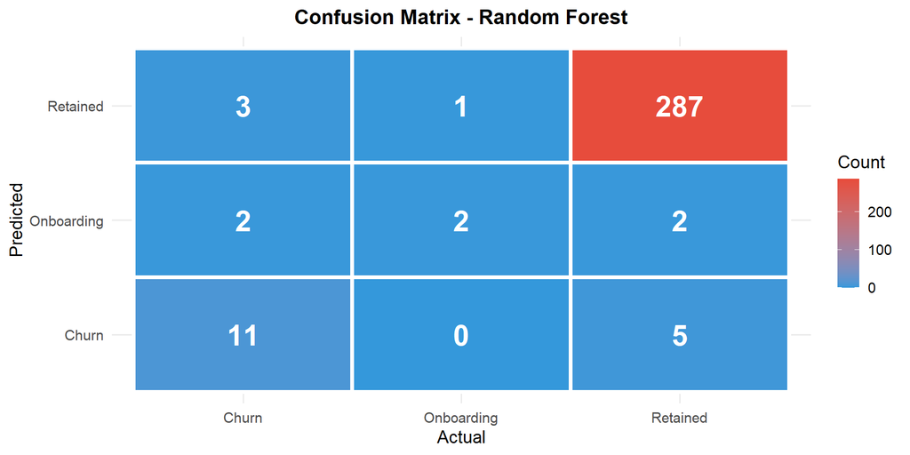

## 6.4 Metrics Visualization

[figure not shown]

## 6.5 ROC Curve (Macro-Averaged)

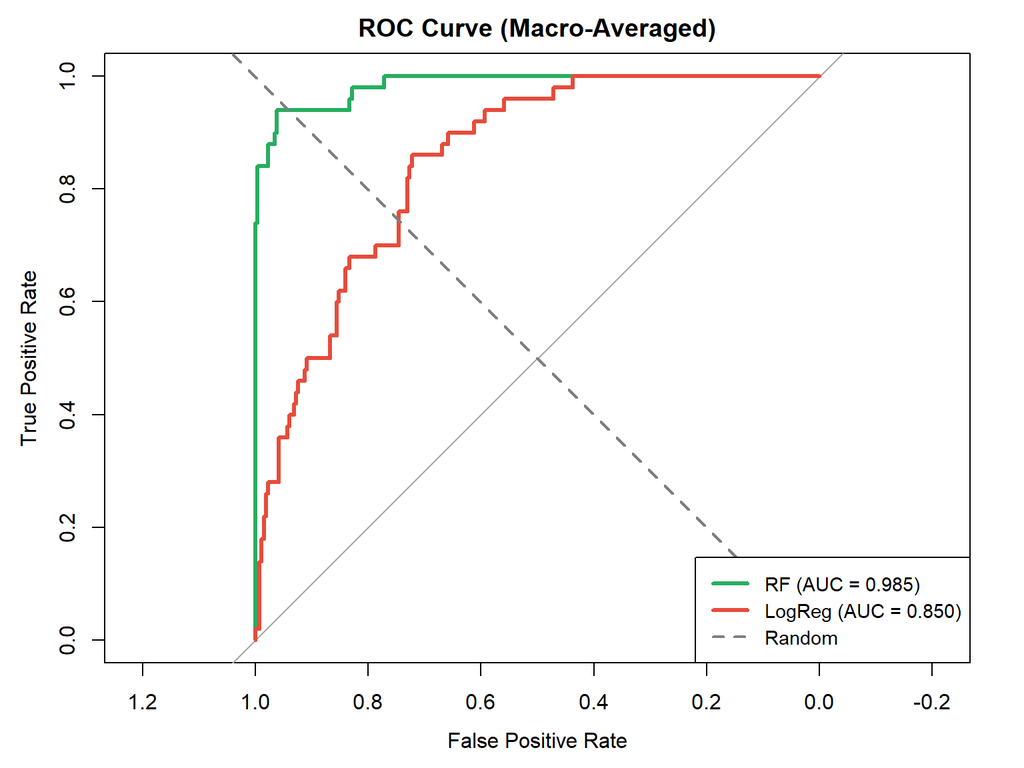

## 6.6 Feature Importance

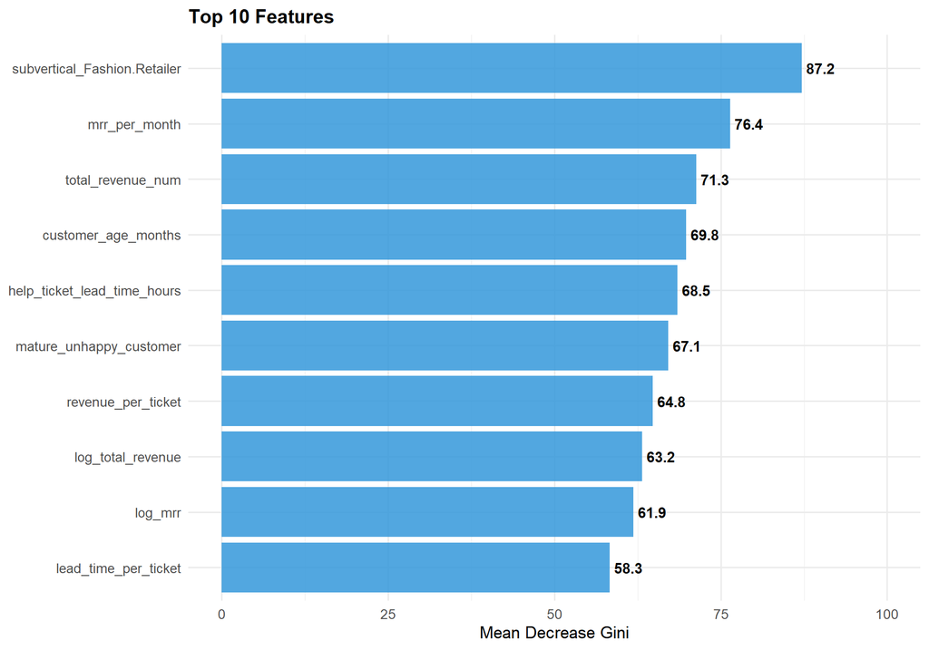

# 7 Conclusion

## 7.1 Summary

1. ✅ 9 CSV integration (LEFT JOIN, ID standardization)
2. ✅ **NO target leakage** (customer_level imputation only)
3. ✅ 13 engineered features
4. ✅ Stratified 80/20 split
5. ✅ **SMOTE on training set ONLY**
6. ✅ Constrained Random Forest

## 7.2 Key Findings

**Top Predictors**: Industry, MRR/month (engineered), customer age, support lead time

**Why RF > LogReg**: Non-linear patterns, auto-interactions, better with imbalance

*End of Report*

**Instructor**: Assist. Prof. Dr. Zeynep Filiz EREN  
**Students**: Doğa Değirmenci (210709003), Hakan Kayacı (210709078), Yeşim Arslan (220709030)